# Métodos estatísticos

Author

Vinícius Oviedo

# Métodos estatísticos

Nesta aula, vamos trabalhar com medidas de estatística descritiva em `Pandas`. Aqui, vamos utilizar um conjunto de dados disponível na biblioteca `seaborn`, uma biblioteca de visualização de dados. O conjunto de dados trata de contas e gorgetas em um restaurante fictício. O conteúdo a ser discutido é:

1. Método `describe()`
2. Obtenção de valores máximo e mínimo, além da amplitdue dos dados
3. Medidas de tendência central: média, mediana e moda
4. Medidas de dispersão: desvio padrão, variância, coeficiente de variação
5. Medidas de posição: quartis, percentis, mediana
6. Outliers via método IQR
7. Correlação entre variáveis.

Primeiramente, vamos carregar o conjunto de dados `tips`, além das bibliotecas necessárias:

```python
import pandas as pd
import seaborn as sns

tips = sns.load_dataset('tips')
tips.head()
```

|  | total_bill | tip | sex | smoker | day | time | size |
| --- | --- | --- | --- | --- | --- | --- | --- |
| 0 | 16.99 | 1.01 | Female | No | Sun | Dinner | 2 |
| 1 | 10.34 | 1.66 | Male | No | Sun | Dinner | 3 |
| 2 | 21.01 | 3.50 | Male | No | Sun | Dinner | 3 |
| 3 | 23.68 | 3.31 | Male | No | Sun | Dinner | 2 |
| 4 | 24.59 | 3.61 | Female | No | Sun | Dinner | 4 |

## 1. Estatísticas descritivas

As estatísticas descritivas podem ser obtidas pelo método `.describe()`

```python
# Vamos mostrar a tabela transposta (T) fins de visualização (linhas viram colunas):
tips.describe().T
```

|  | count | mean | std | min | 25% | 50% | 75% | max |
| --- | --- | --- | --- | --- | --- | --- | --- | --- |
| total_bill | 244.0 | 19.785943 | 8.902412 | 3.07 | 13.3475 | 17.795 | 24.1275 | 50.81 |
| tip | 244.0 | 2.998279 | 1.383638 | 1.00 | 2.0000 | 2.900 | 3.5625 | 10.00 |
| size | 244.0 | 2.569672 | 0.951100 | 1.00 | 2.0000 | 2.000 | 3.0000 | 6.00 |

Nesse *dataframe* de saída temos:

| Coluna | Descrição |
| --- | --- |
| **COUNT** | Contagem |
| **MEAN** | Média |
| **STD** | Desvio padrão |
| **MIN** | Valor mínimo |
| **25%** | Primeiro quartil (`Q1`, 25% dos dados) |
| **50%** | Segundo quartil ou **mediana** (`Q2`, 50% dos dados) |
| **75%** | Terceiro quartil (`Q3`, 75% dos dados) |
| **MAX** | Valor máximo |

### Dica:

> Caso queiramos menter dados categóricos também, podemos incluir a opção `include='all'`.

## 2. Mínimo, máximo e amplitude

Com essas medidas, podemos responder algumas perguntas.

> **Qual foi a gorjeta mínima?**

```python
tips['tip'].min()
```

```
1.0
```

> **Qual foi a maior conta (máximo `total_bill`)?**

```python
tips['total_bill'].max()
```

```
50.81
```

Logo a amplitude dos dados (para a coluna `tip`) pode ser obtida por:

$$A = Max - Min$$

```python
amplitude_gorjetas = tips['tip'].max() - tips['tip'].min()
amplitude_gorjetas
```

```
9.0
```

## 3. Medidas de tendência central

> **Média**

```python
tips['tip'].mean()
```

```
2.99827868852459
```

```python
tips['total_bill'].mode()
```

```
0    13.42
Name: total_bill, dtype: float64
```

> **Moda**

```python
tips['day'].mode()
```

```
0    Sat
Name: day, dtype: category
Categories (4, object): ['Thur', 'Fri', 'Sat', 'Sun']
```

Conferindo:

```python
tips['day'].value_counts()
```

```
day
Sat     87
Sun     76
Thur    62
Fri     19
Name: count, dtype: int64
```

## 4. Medidas de dispersão:

> **Desvio Padrão**

```python
# Amostra (padrão, ddof=1):
print(tips['tip'].std())

# População:
print(tips['tip'].std(ddof=0))
```

```
1.3836381890011822
1.3807999538298954
```

> **Variância**

```python
# Amostra (padrão, ddof=1):
print(tips['tip'].var())

# População:
print(tips['tip'].var(ddof=0))
```

```
1.914454638062471
1.9066085124966412
```

> **Coeficiente de variação (CV)**

```python
# Amostra:
cv_gorjeta = tips['tip'].std(ddof=1) / tips['tip'].mean() *100
cv_gorjeta = round(cv_gorjeta, 2)
print(f' CV para tip: {cv_gorjeta}')
```

```
 CV para tip: 46.15
```

## 5. Medidas de posição:

> **Quartis**

```python
Q1 = tips['tip'].quantile(0.25)
Q2 = tips['tip'].quantile(0.5)
Q3 = tips['tip'].quantile(0.75)

print(f'Q1 (25%): {Q1}')
print(f'Q2 (50%): {Q2}')
print(f'Q3 (75%): {Q3}')
```

```
Q1 (25%): 2.0
Q2 (50%): 2.9
Q3 (75%): 3.5625
```

Isso diz muito sobre a distribuição dos dados e pode ser visualizado por um boxplot:

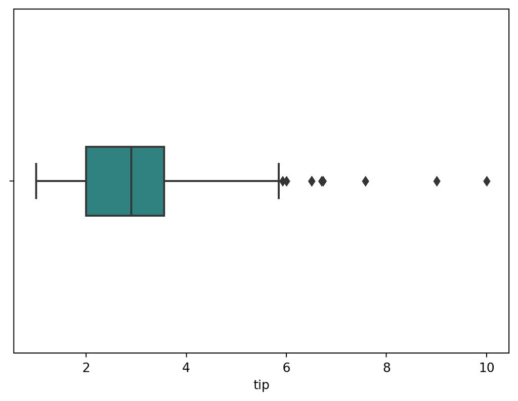

```python
sns.boxplot(data=tips, x='tip', width=0.2, palette='viridis_r')
```

> **Percentis**

```python
# Percentil 90°:
tips['tip'].quantile(0.9)
```

```
5.0
```

## 6. Outliers via método IQR

A partir do conhecimento dos quartis e da distância inter-quartil (IQR), dada pela diferença Q3-Q1, podemos encontrar outliers (valores discrepantes):

$$Outliers \ Inferiores = Q_1 - 1.5 IQR$$

$$Outliers \ Superiores = Q_3 + 1.5 IQR$$

Assim, vamos encontrar outliers para a coluna `total_bill`.

```python
IQR = tips['total_bill'].quantile(0.75) - tips['total_bill'].quantile(0.25)
outliers_inf = tips['total_bill'].quantile(0.25) - 1.5*IQR
outliers_sup = tips['total_bill'].quantile(0.75) + 1.5*IQR

print(f'Outliers inferiores: {outliers_inf}')
print(f'Outliers superiores: {outliers_sup}')
```

```
Outliers inferiores: -2.8224999999999945
Outliers superiores: 40.29749999999999
```

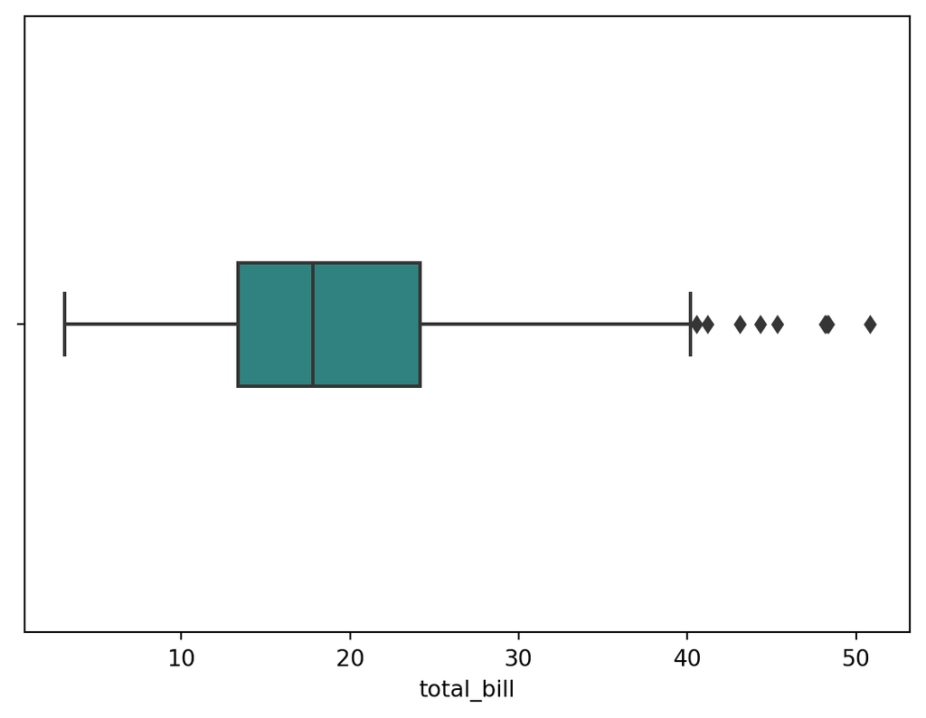

```python
sns.boxplot(data=tips, x='total_bill', width=0.2, palette='viridis_r')
```

## 7. Correlação entre variáveis

> **Paramétrica**

```python
# Default: Pearson
correlacoes = tips[['tip', 'total_bill']].corr(method='pearson')
correlacoes
```

|  | tip | total_bill |
| --- | --- | --- |
| tip | 1.000000 | 0.675734 |
| total_bill | 0.675734 | 1.000000 |

É possível visualizar essas correlção via `heatmap`:

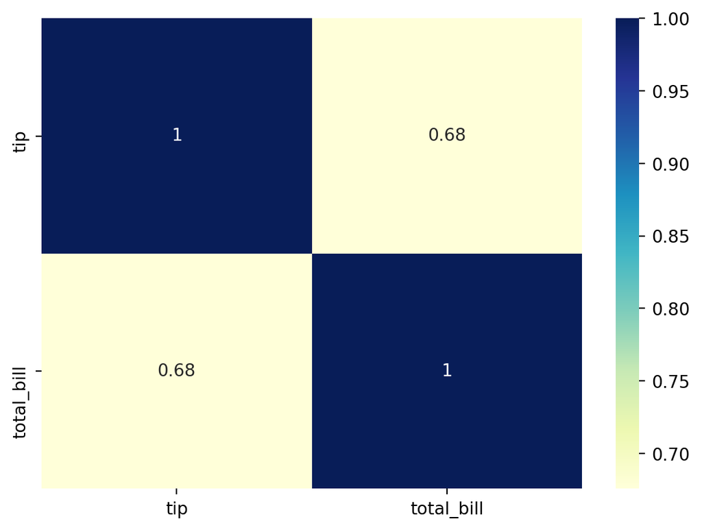

```python
sns.heatmap(correlacoes, annot=True, cmap='YlGnBu')
```

> **Não-paramétrica**

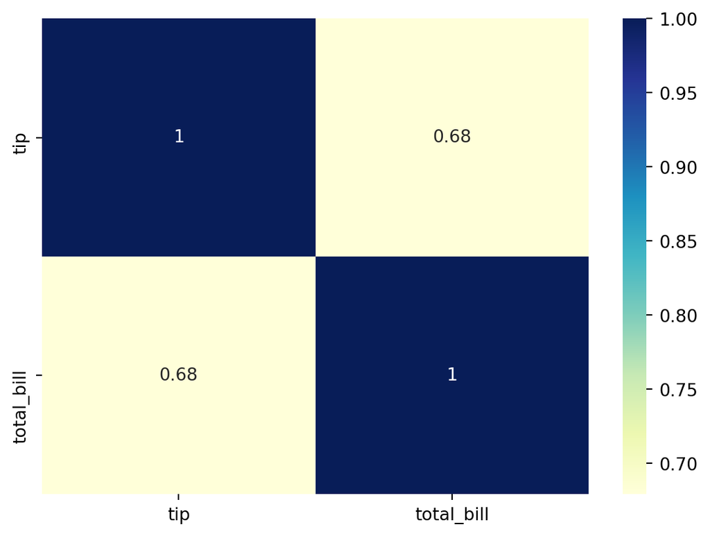

```python
# Default: Pearson
correlacoes_spearman = tips[['tip', 'total_bill']].corr(method='spearman')
sns.heatmap(correlacoes_spearman, annot=True, cmap='YlGnBu')
```